# Atividade 1 - Aula de introdução ao Aprendizado de Máquina

Ricardo J. de Souza, Maíra A. H. do Nascimento, Hanna Diniz, Estevão Vargas, Lívia P. Coelho

02/05/2022

# Objetivo: Classificação usando Regressão Logística E Árvore de Decisão

## Repositório

Documentação e códigos utilizados para criar este documento no link: [introdução ao aprendizado de máquina.](https://github.com/rsouzaj/machine_learning)

## Pacotes utilizados

Pacotes do R utilizados no trabalho:

```
    # tidyverse
    # patchwork
    # caret
    # corrplot
    # corrgram
    # tree
    # xtable
    # flextable
    # smotefamily
    # tree
```

```r
library(tidyverse)

library(caret)
```

## Carregar o banco para análise

Banco de dados utilizado: EXAMES-PNS-2013

```r
banco <- read_csv("EXAMES-PNS-2013-selec.csv", locale = locale(decimal_mark = ","))
# tem que informar para o R o marcador de decimal do arquivo a ser importado.
```

### Visualização dos nomes das variáveis, da dimensão e estrutura do banco de dados

Observamos que os nomes das variáveis estão em códigos, o banco de dados tem 8952 observações e 377 variáveis.

Diversas variáveis apresentam um número significativo de “NAs” e o tratamento será avaliado posteriormente.

```r
names(banco)

glimpse(banco)
```

```r
dim(banco)
```

```
## [1] 8952  377
```

# Desfecho

**Diagnostico de Diabetes mellitus (DM)**

Metodologia:

- Hemoglobina glicada : Diretrizes Sociedade Brasileira de Diabetes 2019-2020(FORTI et al., 2020)
- Diagnóstico prévio de DM

  ```
      # Aspectos técnicos e laboratoriais de diagnóstico e acompanhamento
      do diabetes mellitus.
       DM -> Hb glicada >= 6.5%.

      # Consideramos como diabéticos as pessoas que tiveram diagnóstico
      de diabetes por algum médico, incluindo diabetes gestacional,
      (variável Q030 = 1 ou 2) e/ou hemoglobina glicada >= 6.5%.

      # Z034 Hemoglobina Glicosilada (em %) + Q030 (diagnóstico de dibetes
      por médico, incluindo gestacional)
  ```

Número de pacientes com a Hb glicada elevada

```
      Ao todo, 595 pessoas tinham a Hb glicada acima de 6.5%
```

```r
banco <- banco %>%
  mutate(hb_glic = if_else(Z034 >= 6.5, "Sim", "Não"))

banco %>%
  group_by(hb_glic) %>%
  summarise(N = n())
```

| hb_glic | N |
| --- | --- |
| Não | 7946 |
| Sim | 595 |
| NA | 411 |

Número de pacientes com diagnóstico prévio de diabetes.

```
      Nessa população, 640 pessoas foram previamente diagnosticadas com DM.
```

```r
banco <- banco %>%
  mutate(diabetes_prev = if_else(Q030 == 1 | Q030 == 2, "Sim", "Não"))

banco %>%
  group_by(diabetes_prev) %>%
  summarise(N = n())
```

| diabetes_prev | N |
| --- | --- |
| Não | 7225 |
| Sim | 640 |
| NA | 1087 |

Relação entre pacientes com Hb glicada elevada e diagnóstico prévio de diabetes.

```
    Incluindo as duas condições anteriores, temos 923 pacientes com diabetes
    por uma e/ou outra condição.
```

```r
banco %>%
  group_by(diabetes_prev, hb_glic) %>%
  summarise(N = n())
```

| diabetes_prev | hb_glic | N |
| --- | --- | --- |
| Não | Não | 6643 |
| Não | Sim | 260 |
| Não | NA | 322 |
| Sim | Não | 300 |
| Sim | Sim | 312 |
| Sim | NA | 28 |
| NA | Não | 1003 |
| NA | Sim | 23 |
| NA | NA | 61 |

```r
banco <- banco %>%
  mutate(diabetes = if_else(Z034 >= 6.5 | Q030 == 1 | Q030 == 2 , "Sim", "Não"))
# criação da variável 'diabetes' de acordo com os parâmetros definidos.
```

Visualização da distribuição de diabetes na população de estudo

```r
banco %>%
  group_by(diabetes) %>%
  summarise(N = n())
```

| diabetes | N |
| --- | --- |
| Não | 6643 |
| Sim | 923 |
| NA | 1386 |

# Variáveis preditoras

A variáveis preditoras foram selecionadas com base no artigo de Nascimento et. al.(NASCIMENTO et al., 2003)

dicionário de variáveis do banco de dados.

```
  Variáveis preditoras de acordo com o dicionário:

  # Z001    Sexo
  #         1   Masculino
  #         2   Feminino

  # Z002    Idade       Anos

  # IMC:
      imc = peso(kg)/altura(m)^2
      z004 = peso (kg); z005 = altura em cm.
  # imc = Z004 / ((Z005)/100)^2)

  # W00303 -> Circunferência da cintura - Final (em cm)

  # Z031    Colesterol Total (em mg/dL)
  # Z032    HDL Colesterol (em mg/dL)
  # Z033    LDL Colesterol (em mg/dL)

  # vldl = Z031- (Z032 + Z033) # segundo Nascimento et. al., o nível de vldl
  foi a variável com maior correlação com risco de diabetes

  # Z003    Cor ou raça
          #         1   Branca
          #         2   Preta
          #         3   Amarela
          #         4   Parda
          #         5   Indígena
          #         9   Ignorado

  # regiao -> Região do país -> pode haver alguma relação com o tipo de
  alimentação
        # 1 Norte
        # 2 Nordeste
        # 3 Sudeste
        # 4 Sul
        # 5 Centro-Oeste

  # VDD004 ->   Nível de instrução mais elevado alcançado (pessoas de 5 anos
  ou mais de idade)
                #       1   Sem instrução
                #       2   Fundamental incompleto ou equivalente
                #       3   Fundamental completo ou equivalente
                #       4   Médio incompleto ou equivalente
                #       5   Médio completo ou equivalente
                #       6   Superior incompleto ou equivalente
                #       7   Superior completo
                #       .   Não aplicável
```

## Banco de trabalho

Seleção de variáveis:

```
  Obs: criação de variável vldl e imc.
```

```r
banco_trab <- banco %>%
  mutate(
    vldl = (Z031- (Z032+ Z033)), # VLDL = Colesterol total - (HDL + LDL)
    imc = round((z004 / ((z005)/100)^2), digits = 1)) %>%
  # arredonda o IMC com uma casa decimal
  select(diabetes, Z001, Z002,imc, W00303, Z031:Z033,vldl, Z003, VDD004, regiao)
```

### Detalhes do banco de trabalho

```r
glimpse(banco_trab)
```

```
## Rows: 8,952
## Columns: 12
## $ diabetes <chr> "Não", "Não", "Não", "Não", "Não", NA, "Não", "Não", "Não", "~
## $ Z001     <dbl> 1, 2, 1, 1, 1, 1, 1, 1, 1, 1, 2, 2, 2, 1, 1, 1, 1, 1, 2, 2, 1~
## $ Z002     <dbl> 82, 46, 64, 65, 71, 83, 33, 41, 62, 80, 49, 53, 61, 34, 36, 3~
## $ imc      <dbl> 33.9, 20.8, 20.1, 23.2, 29.2, 25.3, 28.4, 30.2, 22.9, 21.7, 2~
## $ W00303   <dbl> 110.4, 77.3, 78.4, 96.5, 102.5, 97.0, 95.8, 104.0, 89.0, 97.0~
## $ Z031     <dbl> 156, 129, 158, 126, 220, 164, 226, 206, 172, 208, 107, 209, 2~
## $ Z032     <dbl> 27, 42, 37, 31, 40, 38, 36, 37, 44, 40, 38, 44, 68, 39, 46, 2~
## $ Z033     <dbl> 97, 72, 88, 58, 119, 93, 134, 133, 91, 133, 48, 130, 162, 99,~
## $ vldl     <dbl> 32, 15, 33, 37, 61, 33, 56, 36, 37, 35, 21, 35, 26, 51, 38, 3~
## $ Z003     <dbl> 1, 2, 1, 1, 1, 1, 1, 1, 1, 1, 2, 2, 2, 1, 1, 1, 1, 1, 2, 2, 1~
## $ VDD004   <dbl> 1, 3, 1, 1, 1, 1, 3, 3, 3, 3, 3, 3, 3, 5, 5, 5, 5, 7, 3, 4, 3~
## $ regiao   <dbl> 1, 5, 1, 1, 1, 1, 5, 5, 2, 2, 1, 1, 1, 1, 1, 1, 1, 1, 1, 1, 4~
```

Transformação das variáveis categóricas em fatores

```
  As variáveis que foram importadas como números foram recodificadas como fatores.
```

```r
banco_trab$Z001 <- as.factor(banco_trab$Z001)
banco_trab$VDD004 <- as.factor(banco_trab$VDD004)
banco_trab$regiao <- as.factor(banco_trab$regiao)
```

### Avaliação da quantidade de “NAs” e porcentagem por variável

Qual o máximo de NAs aceitáveis?(DZIURA et al., 2013)

```
  Dependendo do tipo de estudo, pode ser aceitável entre 5 a 25%.
  O ideal seria de 5% no máximo, mas são aceitáveis em alguns casos até 25%.
  Nós definimos que as variáveis deveriam ter menos do que 10% de "missing"
  para serem incluídas na análise.
```

```r
banco_trab %>%
  summarise(N = n()) %>%
  tibble(Variaveis = colnames(banco_trab),
         Missing =  colSums(is.na(banco_trab)),
         Porcentagem = (colSums(is.na(banco_trab))*100/N)
  ) %>%
  select(Variaveis:Porcentagem) %>%
  arrange((Porcentagem)) %>%
  xtable::xtable() %>%
  flextable::as_flextable() %>%
  flextable::footnote(j = 2:4, part = 'header',
                      value = flextable::as_paragraph(
                        c(Variaveis = "Variáveis observadas;",
                          Missing = "Número de valores não observados;",
                          Porcentagem = "Relação entre os valores não observados e
                          o total de observações de cada variável (%).")),
                      ref_symbols = c("a", "b", "c")
                      )
```

|  | Variaveisa | Missingb | Porcentagemc |
| --- | --- | --- | --- |
| 1 | Z001 | 0.0 | 0.0 |
| 2 | Z002 | 0.0 | 0.0 |
| 3 | Z003 | 0.0 | 0.0 |
| 4 | VDD004 | 0.0 | 0.0 |
| 5 | regiao | 6.0 | 0.1 |
| 6 | imc | 97.0 | 1.1 |
| 7 | W00303 | 97.0 | 1.1 |
| 8 | Z031 | 418.0 | 4.7 |
| 9 | Z033 | 418.0 | 4.7 |
| 10 | Z032 | 432.0 | 4.8 |
| 11 | vldl | 434.0 | 4.8 |
| 12 | diabetes | 1,386.0 | 15.5 |

aVariáveis observadas;  
bNúmero de valores não observados;  
cRelação entre os valores não observados e o total de observações de cada variável (%).

### Análise exploratória

Após definirmos a variável desfecho e as possíveis preditoras, inicamos a análise exploratória.

```r
summary(banco_trab)
```

```
##    diabetes         Z001          Z002             imc            W00303
##  Length:8952        1:3725   Min.   : 18.00   Min.   :13.10   Min.   : 50.00
##  Class :character   2:5227   1st Qu.: 34.00   1st Qu.:23.00   1st Qu.: 81.50
##  Mode  :character            Median : 45.00   Median :26.00   Median : 90.50
##                              Mean   : 46.84   Mean   :26.57   Mean   : 91.12
##                              3rd Qu.: 58.00   3rd Qu.:29.40   3rd Qu.: 99.90
##                              Max.   :104.00   Max.   :61.30   Max.   :149.70
##                                               NA's   :97      NA's   :97
##       Z031          Z032             Z033            vldl
##  Min.   : 67   Min.   :  6.00   Min.   : 22.0   Min.   :-25.00
##  1st Qu.:160   1st Qu.: 37.00   1st Qu.: 84.0   1st Qu.: 25.00
##  Median :184   Median : 45.00   Median :103.0   Median : 32.00
##  Mean   :187   Mean   : 45.98   Mean   :105.5   Mean   : 35.53
##  3rd Qu.:211   3rd Qu.: 53.00   3rd Qu.:124.0   3rd Qu.: 42.00
##  Max.   :433   Max.   :160.00   Max.   :261.0   Max.   :288.00
##  NA's   :418   NA's   :432      NA's   :418     NA's   :434
##       Z003       VDD004    regiao
##  Min.   :1.000   1:1685   1   :2297
##  1st Qu.:1.000   2:2293   2   :3053
##  Median :2.000   3: 941   3   :1514
##  Mean   :1.584   4: 443   4   :1075
##  3rd Qu.:2.000   5:2291   5   :1007
##  Max.   :2.000   6: 380   NA's:   6
##                  7: 919
```

Após a análise inicial, verificamos que as variáveis Z001(sexo) e Z003(raça) tinham seus preenchimentos idênticos. Como a raça estava com preenchimento binário (1,2), assumimos que houve erro no preencimento dessa variável.

```r
table(banco_trab$Z001, banco_trab$Z003)
```

```
##
##        1    2
##   1 3725    0
##   2    0 5227
```

Exclusão da variável raça (Z003).

```r
banco_trab <- banco_trab %>% select(everything(), -Z003)
```

### Lidando com NAs da variável de desfecho

```
    Dúvida: não seria melhor primeiro imputar dados faltantes nas variáveis
    preditoras antes de eliminar grande parte do banco de dados? Perderemos
    mais de 1300 observações retirando os NAs do desfecho.
    Preferimos imputar os missings pelas médias (retirando-se os outliers) antes
    de retirar os faltantes da variável de desfecho.

    Talvez a melhor opção seja aplicar a mediana nas varáveis com muitos outliers.
```

## Visualização dos dados

#### Testes de outliers

Box plot:

- **Idade**

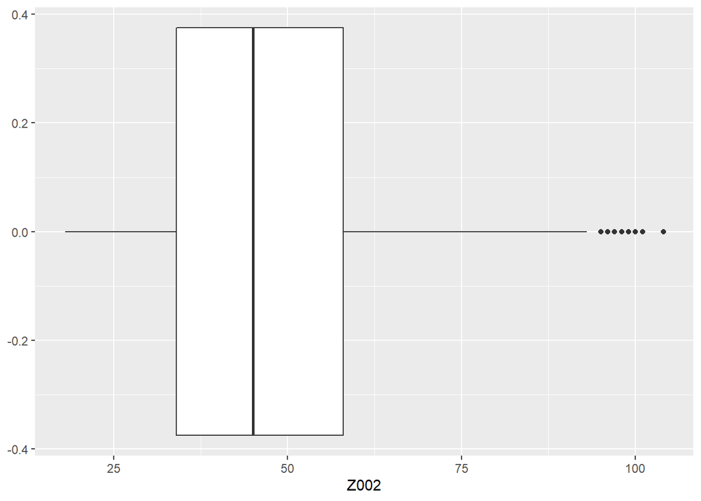

```r
banco_trab %>%
  ggplot(aes(Z002))+
  geom_boxplot()
```

- **IMC**

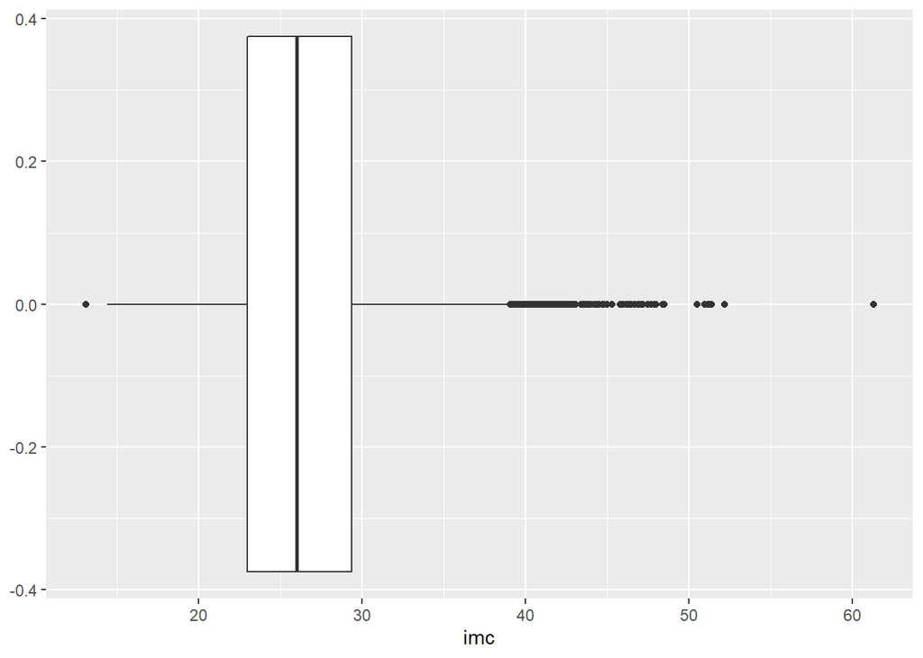

```r
banco_trab %>%
  ggplot(aes(imc))+
  geom_boxplot()
```

- **Circunferência da cintura**

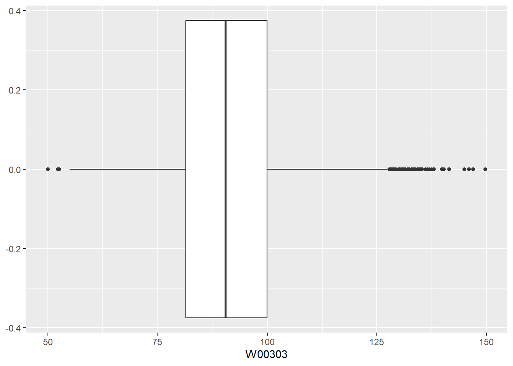

```r
banco_trab %>%
  ggplot(aes(W00303))+
  geom_boxplot()
```

- **VLDL**

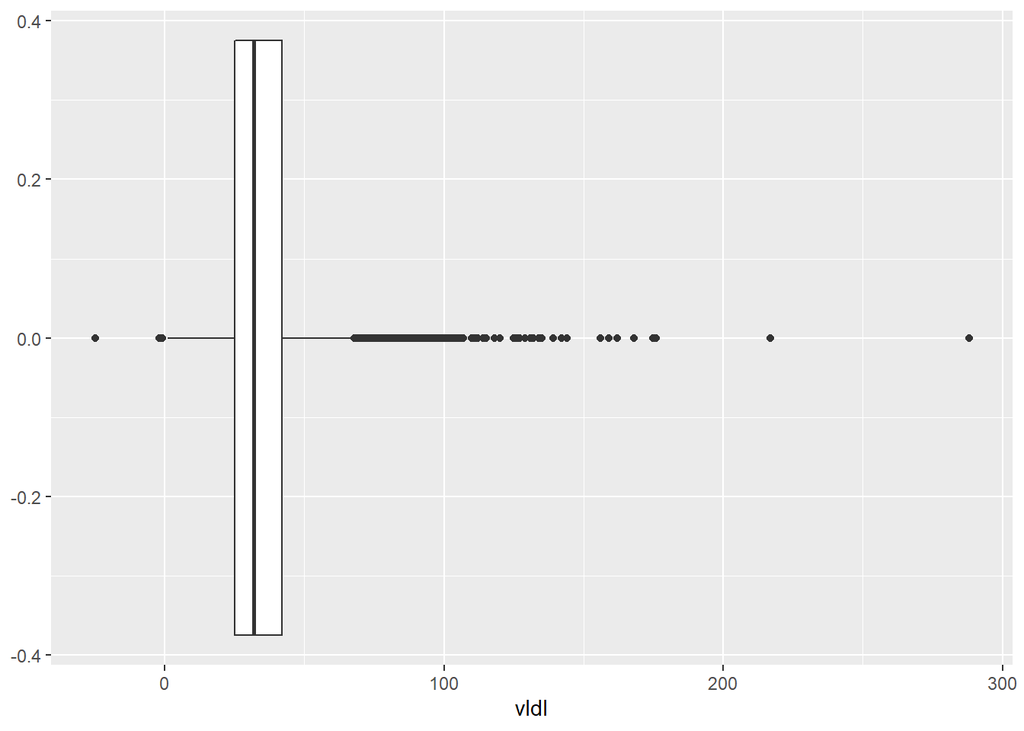

```r
banco_trab %>%
  ggplot(aes(vldl))+
  geom_boxplot()
```

### Teste outliers

```
  Ausência de verdadeiros outliers em idade
```

```r
  test <- EnvStats::rosnerTest(banco_trab$Z002, k=8)

test$all.stats
```

| i | Mean.i | SD.i | Value | Obs.Num | R.i+1 | lambda.i+1 | Outlier |
| --- | --- | --- | --- | --- | --- | --- | --- |
| 0 | 46.84428 | 16.45230 | 104 | 7839 | 3.474026 | 4.539019 | FALSE |
| 1 | 46.83790 | 16.44212 | 101 | 3403 | 3.294106 | 4.538995 | FALSE |
| 2 | 46.83184 | 16.43307 | 100 | 810 | 3.235437 | 4.538971 | FALSE |
| 3 | 46.82590 | 16.42437 | 100 | 4108 | 3.237512 | 4.538947 | FALSE |
| 4 | 46.81996 | 16.41567 | 99 | 2809 | 3.178673 | 4.538924 | FALSE |
| 5 | 46.81413 | 16.40731 | 99 | 3692 | 3.180647 | 4.538900 | FALSE |
| 6 | 46.80829 | 16.39895 | 98 | 2114 | 3.121646 | 4.538876 | FALSE |
| 7 | 46.80257 | 16.39093 | 98 | 2745 | 3.123522 | 4.538852 | FALSE |

```
  Valores de IMC acima de 50  foram considerados outliers
```

```r
  test <- EnvStats::rosnerTest(banco_trab$imc, k=20)

test$all.stats
```

| i | Mean.i | SD.i | Value | Obs.Num | R.i+1 | lambda.i+1 | Outlier |
| --- | --- | --- | --- | --- | --- | --- | --- |
| 0 | 26.57346 | 5.096999 | 61.3 | 171 | 6.813134 | 4.536699 | TRUE |
| 1 | 26.56954 | 5.083906 | 52.2 | 2849 | 5.041490 | 4.536674 | TRUE |
| 2 | 26.56664 | 5.076889 | 51.4 | 798 | 4.891451 | 4.536650 | TRUE |
| 3 | 26.56384 | 5.070309 | 51.3 | 3581 | 4.878630 | 4.536626 | TRUE |
| 4 | 26.56104 | 5.063772 | 51.2 | 5349 | 4.865731 | 4.536602 | TRUE |
| 5 | 26.55826 | 5.057280 | 51.0 | 1203 | 4.832982 | 4.536578 | TRUE |
| 6 | 26.55550 | 5.050885 | 50.5 | 8900 | 4.740655 | 4.536554 | TRUE |
| 7 | 26.55279 | 5.044751 | 48.5 | 3323 | 4.350504 | 4.536530 | FALSE |
| 8 | 26.55031 | 5.039636 | 48.4 | 7263 | 4.335569 | 4.536506 | FALSE |
| 9 | 26.54784 | 5.034563 | 48.0 | 7100 | 4.260978 | 4.536482 | FALSE |

[output cut: 10 more lines]

```
Valores acima de 100mg/dl foram considerados outliers no test. Temos que avaliar
a retirada do cálculo da média para imputação dos NAs ou utilizar a mediana.
Mas vamos manter para avaliação dos modelos preditivos e retirar somente se
melhorarem a predição.
```

```r
  test <- EnvStats::rosnerTest(banco_trab$vldl, k=67)

test$all.stats
```

| i | Mean.i | SD.i | Value | Obs.Num | R.i+1 | lambda.i+1 | Outlier |
| --- | --- | --- | --- | --- | --- | --- | --- |
| 0 | 35.53135 | 16.48751 | 288 | 8925 | 15.312719 | 4.528425 | TRUE |
| 1 | 35.50170 | 16.25990 | 217 | 1972 | 11.162325 | 4.528400 | TRUE |
| 2 | 35.48039 | 16.14145 | 176 | 5622 | 8.705515 | 4.528374 | TRUE |
| 3 | 35.46389 | 16.07039 | 175 | 462 | 8.682808 | 4.528349 | TRUE |
| 4 | 35.44750 | 16.00001 | 168 | 599 | 8.284526 | 4.528324 | TRUE |
| 5 | 35.43193 | 15.93631 | 162 | 17 | 7.942118 | 4.528299 | TRUE |
| 6 | 35.41706 | 15.87808 | 159 | 8783 | 7.783242 | 4.528274 | TRUE |
| 7 | 35.40254 | 15.82239 | 156 | 5581 | 7.621948 | 4.528249 | TRUE |
| 8 | 35.38837 | 15.76922 | 144 | 529 | 6.887574 | 4.528224 | TRUE |
| 9 | 35.37560 | 15.72612 | 142 | 3003 | 6.780085 | 4.528199 | TRUE |

[output cut: 57 more lines]

### Gráficos de caixa entre variável desfecho e variáveis numéricas

```
  Observamos que os pacientes mais com diabetes são mais idosos em geral, tem
  o IMC, circunferência abdominal mais elevados.
```

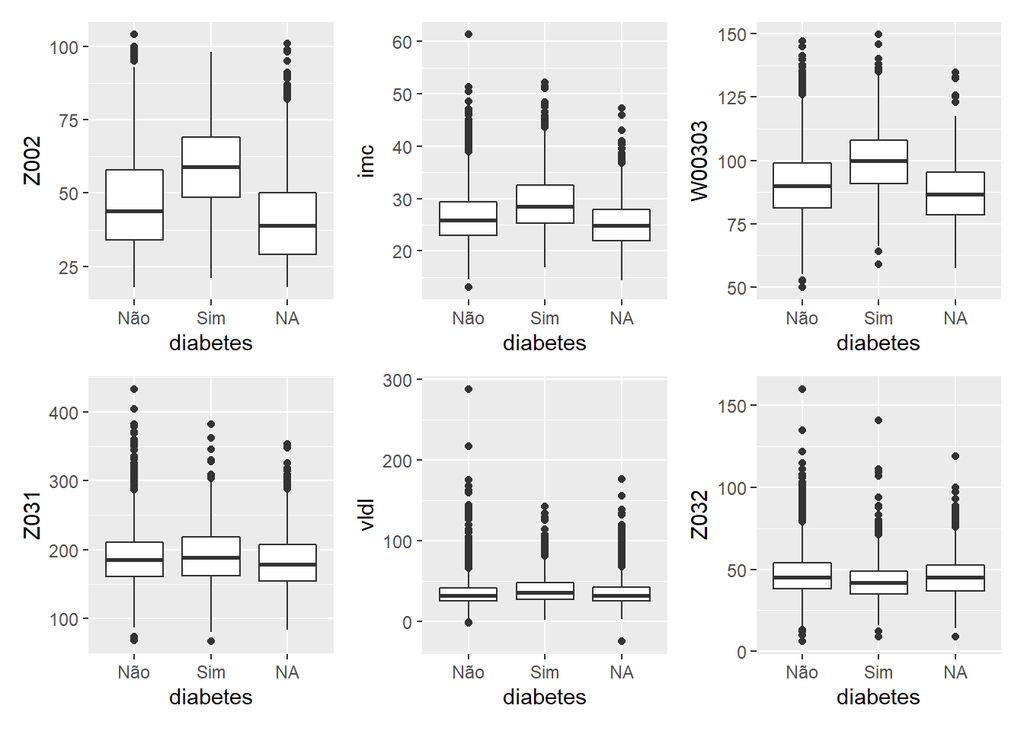

```r
library(patchwork)

g1 <- ggplot(banco_trab, aes(diabetes, Z002)) +
  geom_boxplot()

g2 <- ggplot(banco_trab, aes(diabetes, imc)) +
  geom_boxplot()

g3 <- ggplot(banco_trab, aes(diabetes, W00303)) +
  geom_boxplot()

g4 <- ggplot(banco_trab, aes(diabetes, Z031)) +
  geom_boxplot()

g5 <- ggplot(banco_trab, aes(diabetes, vldl)) +
  geom_boxplot()

g6 <- ggplot(banco_trab, aes(diabetes, Z032)) +
  geom_boxplot()

g1 + g2 + g3 + g4 + g5 + g6
```

### Gráficos de dispersão

```
  W00303 -> Circunferência da cintura parece ter uma correlação linear com o IMC.
```

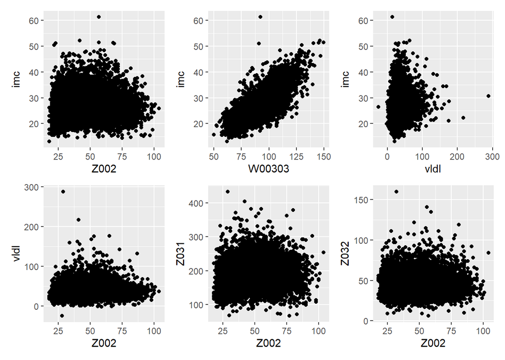

```r
g5 <- ggplot(banco_trab, aes(Z002, imc))+
  geom_point()

g6 <- ggplot(banco_trab, aes(W00303, imc))+
  geom_point()

g7 <- ggplot(banco_trab, aes(vldl, imc))+
  geom_point()

g8 <- ggplot(banco_trab, aes(Z002, vldl))+
  geom_point()

g9 <- ggplot(banco_trab, aes(Z002, Z031))+
  geom_point()

g10 <- ggplot(banco_trab, aes(Z002, Z032))+
  geom_point()

g5 + g6 + g7 + g8 + g9 + g10
```

### Análise do IMC vs circunferência abdominal por diagnóstico de diabetes

```
  Como esperado, independentemente de diabetes a relação entre
  IMC e circunferência abdominal permanece linear. Porém, as pessoas com DM têm valores mais elevados de IMC e circunferência da cintura do que os sem diabetes.
```

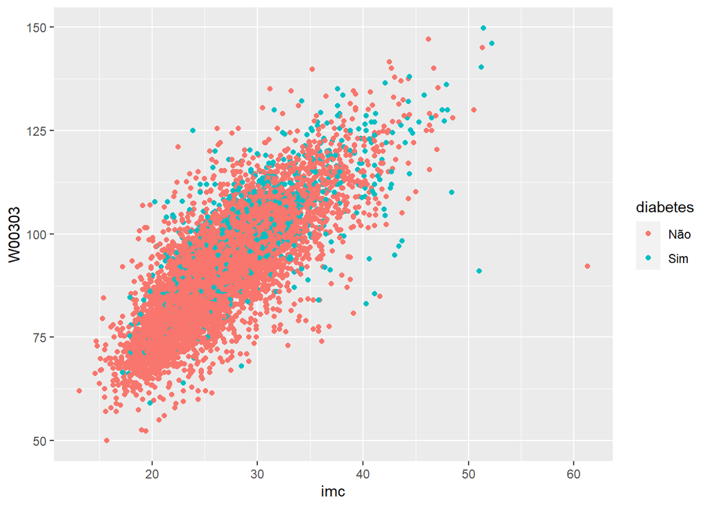

```r
banco_trab %>%
  filter(!is.na(diabetes)) %>%
  ggplot(aes(imc, W00303))+
  geom_point(aes(color = diabetes))
```

# Particionamento dos dados entre treino (70%) e teste(30%)

```r
set.seed(789)
particionamento <- caret::createDataPartition(banco_trab$diabetes,
                                       # cria as partições de forma estratificada
                                        p = 0.70,
                                        list = FALSE)
#O parâmetro list = FALSE evita que o resultado seja armazenado em formato de lista.

banco_train <- banco_trab[particionamento, ]
banco_test <- banco_trab[-particionamento, ]
```

### Visualização do balanceamento

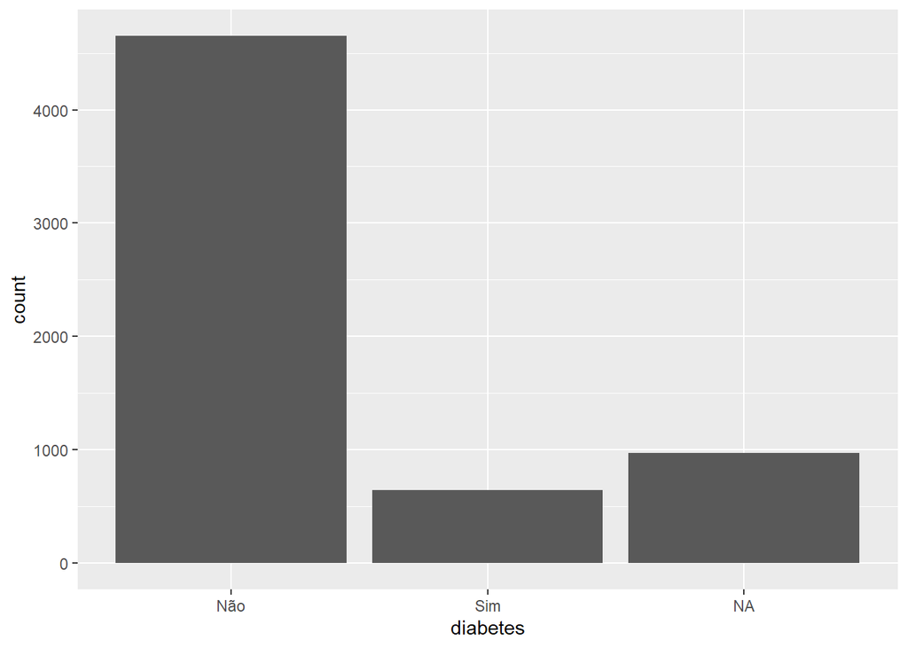

```r
banco_train %>% ggplot(aes(x=diabetes)) + geom_bar(stat="count")
```

Relação diabetes no conjunto treinamento.

```r
table(banco_train$diabetes)
```

```
##
##  Não  Sim
## 4651  647
```

## Pré-processamento conjunto de treino

Sumário do banco treino.

```r
summary(banco_train)
```

```
##    diabetes         Z001          Z002             imc            W00303
##  Length:6269        1:2613   Min.   : 18.00   Min.   :13.10   Min.   : 55.0
##  Class :character   2:3656   1st Qu.: 34.00   1st Qu.:22.95   1st Qu.: 81.5
##  Mode  :character            Median : 45.00   Median :26.00   Median : 90.5
##                              Mean   : 46.97   Mean   :26.58   Mean   : 91.2
##                              3rd Qu.: 58.00   3rd Qu.:29.40   3rd Qu.: 99.8
##                              Max.   :104.00   Max.   :61.30   Max.   :149.7
##                                               NA's   :58      NA's   :58
##       Z031            Z032             Z033            vldl        VDD004
##  Min.   : 67.0   Min.   :  6.00   Min.   : 22.0   Min.   :-25.00   1:1182
##  1st Qu.:160.0   1st Qu.: 37.00   1st Qu.: 85.0   1st Qu.: 25.00   2:1589
##  Median :184.0   Median : 44.00   Median :104.0   Median : 32.00   3: 671
##  Mean   :187.3   Mean   : 45.88   Mean   :105.7   Mean   : 35.64   4: 319
##  3rd Qu.:212.0   3rd Qu.: 53.00   3rd Qu.:124.0   3rd Qu.: 42.00   5:1600
##  Max.   :404.0   Max.   :160.00   Max.   :261.0   Max.   :217.00   6: 272
##  NA's   :291     NA's   :304      NA's   :292     NA's   :305      7: 636
##   regiao
##  1   :1623
##  2   :2135
##  3   :1065
##  4   : 747
##  5   : 694
##  NA's:   5
##
```

### Preenchendo os faltantes pela média

```
    Decidimos filtrar os outliers antes de tirar a média para preencher os dados faltantes.

    Obs: IMC > 50 e VLDL > 100.
```

```r
media_imc <- banco_train %>%
  filter(imc < 50)


banco_train$imc[is.na(banco_train$imc)] <- mean(media_imc$imc, na.rm = T)
# preenche pela média sem outliers

media_vldl <- banco_train %>%
  filter(vldl <= 100)

banco_train$vldl[which(is.na(banco_train$vldl))] <- mean(media_vldl$vldl, na.rm = T)
# preenche pela média sem outliers


banco_train$W00303[which(is.na(banco_train$W00303))] <- mean(banco_train$W00303, na.rm = T)

banco_train$Z031[which(is.na(banco_train$Z031))] <- mean(banco_train$Z031, na.rm = T)

banco_train$Z032[is.na(banco_train$Z032)] <- mean(banco_train$Z032, na.rm = T)

banco_train$Z033[is.na(banco_train$Z033)] <- mean(banco_train$Z033, na.rm = T)
```

[output not shown]

```r
banco_train <- banco_train %>%
  mutate(
    regiao = replace_na(regiao, '5')
    # poderia usar essa função (replace_na) para substituir os NAs das outras variáveis.
  )
```

```r
summary(banco_train)
```

```
##    diabetes         Z001          Z002             imc            W00303
##  Length:6269        1:2613   Min.   : 18.00   Min.   :13.10   Min.   : 55.0
##  Class :character   2:3656   1st Qu.: 34.00   1st Qu.:23.00   1st Qu.: 81.5
##  Mode  :character            Median : 45.00   Median :26.10   Median : 90.8
##                              Mean   : 46.97   Mean   :26.58   Mean   : 91.2
##                              3rd Qu.: 58.00   3rd Qu.:29.40   3rd Qu.: 99.6
##                              Max.   :104.00   Max.   :61.30   Max.   :149.7
##
##       Z031            Z032             Z033            vldl        VDD004
##  Min.   : 67.0   Min.   :  6.00   Min.   : 22.0   Min.   :-25.00   1:1182
##  1st Qu.:161.0   1st Qu.: 38.00   1st Qu.: 86.0   1st Qu.: 26.00   2:1589
##  Median :187.0   Median : 45.00   Median :105.0   Median : 33.00   3: 671
##  Mean   :187.3   Mean   : 45.88   Mean   :105.7   Mean   : 35.62   4: 319
##  3rd Qu.:210.0   3rd Qu.: 52.00   3rd Qu.:123.0   3rd Qu.: 41.00   5:1600
##  Max.   :404.0   Max.   :160.00   Max.   :261.0   Max.   :217.00   6: 272
##                                                                    7: 636
##  regiao
##  1:1623
##  2:2135
##  3:1065
##  4: 747
##  5: 699
##
##
```

## Retirando as observações com ‘missing’ na variável desfecho

```
  Retirar dos dois bancos.
```

```r
banco_train <- banco_train %>%
  filter(!is.na(diabetes))
```

### Padronização das variáveis numéricas

```
  Preferimos criar um banco com as variáveis numéricas padronizadas,
  testando e comparando com o não padronizado, que é mais fácil de interpretar.
```

```r
banco_train_pad <- banco_train %>%
  mutate(
    Z002 = scale(Z002),
    imc = scale(imc),
    W00303 = scale(W00303),
    Z031 = scale(Z031),
    Z032 = scale(Z032),
    Z033 = scale(Z033),
    vldl = scale(vldl)
    )
```

Correlação entre variáveis numéricas padronizadas.

[output not shown]

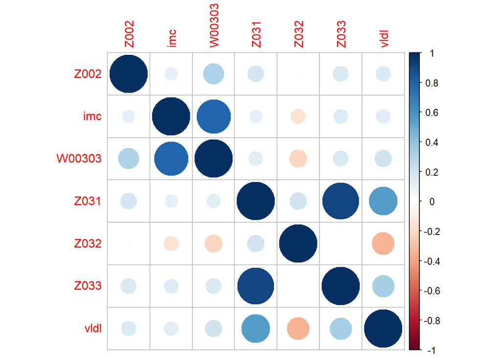

```
  A correção entre Colesterol total e LDL é de mais de 90% vamos analisar qual deve
  ser retirada do modelo. Talvez o melhor seja retirar o colesterol total, pois é
  resultado da soma de três variáveis (VLD, HDL E LDL).
  A correlação entre IMC e circubferência abdominal é de 79%, vamos testar as duas no
  modelo, mas é possível que precise retirar uma delas.
```

```r
correl <- banco_train_pad %>%
  select(where(is.numeric)) %>%
  cor(use = "pairwise")  # não estava funcionando da outra forma (sem o 'pairwise').

corrplot::corrplot(correl, method = 'circle')
```

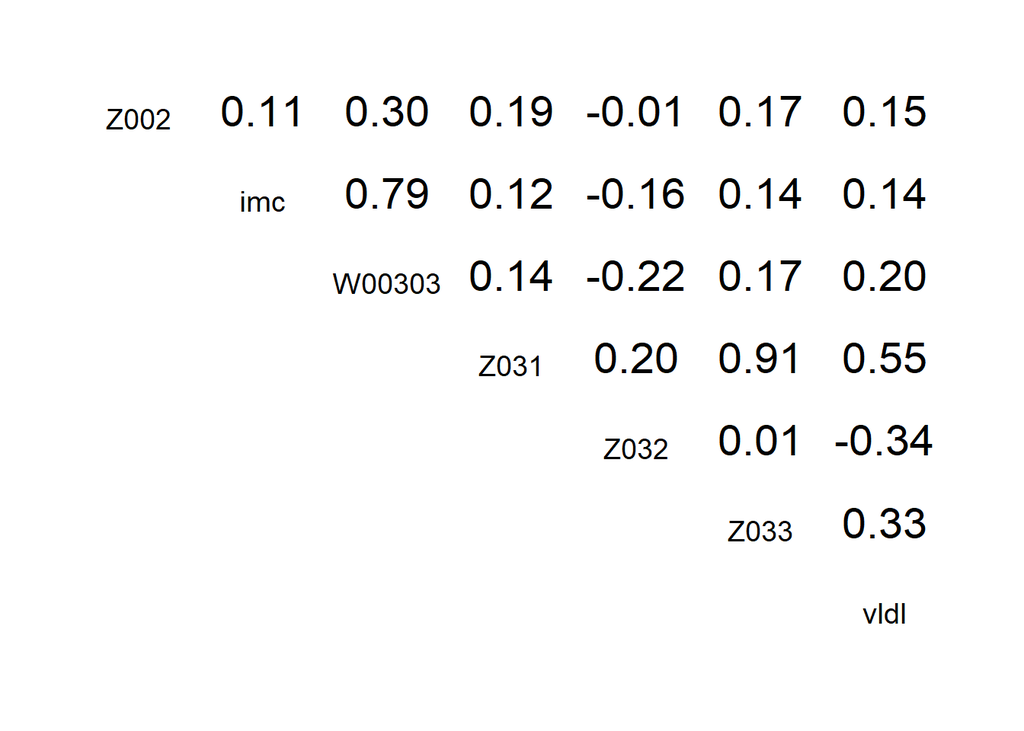

```r
library(corrgram)
corrgram::corrgram(correl, lower.panel = panel.pts, upper.panel= panel.conf,
                   diag.panel = panel.density)
```

### Associação entre variáveis numéricas e desfecho

```
  A única variável sem significância estatística foi o LDL.
```

```r
t.test(banco_train_pad$Z002 ~ banco_train_pad$diabetes) #idade
```

```
##
##  Welch Two Sample t-test
##
## data:  banco_train_pad$Z002 by banco_train_pad$diabetes
## t = -18.68, df = 872.55, p-value < 2.2e-16
## alternative hypothesis: true difference in means between group Não and group Sim is not equal to 0
## 95 percent confidence interval:
##  -0.7907109 -0.6403535
## sample estimates:
## mean in group Não mean in group Sim
##        -0.0873819         0.6281503
```

```r
t.test(banco_train_pad$imc ~ banco_train_pad$diabetes)
```

```
##
##  Welch Two Sample t-test
##
## data:  banco_train_pad$imc by banco_train_pad$diabetes
## t = -11.999, df = 776.61, p-value < 2.2e-16
## alternative hypothesis: true difference in means between group Não and group Sim is not equal to 0
## 95 percent confidence interval:
##  -0.6589675 -0.4736696
## sample estimates:
## mean in group Não mean in group Sim
##        -0.0691597         0.4971588
```

```r
t.test(banco_train_pad$W00303 ~ banco_train_pad$diabetes) #circunferência cintura
```

```
##
##  Welch Two Sample t-test
##
## data:  banco_train_pad$W00303 by banco_train_pad$diabetes
## t = -16.872, df = 820.41, p-value < 2.2e-16
## alternative hypothesis: true difference in means between group Não and group Sim is not equal to 0
## 95 percent confidence interval:
##  -0.7927467 -0.6275139
## sample estimates:
## mean in group Não mean in group Sim
##       -0.08672221        0.62340805
```

```r
t.test(banco_train_pad$Z031 ~ banco_train_pad$diabetes) # Colesterol total
```

```
##
##  Welch Two Sample t-test
##
## data:  banco_train_pad$Z031 by banco_train_pad$diabetes
## t = -2.2792, df = 801.35, p-value = 0.02292
## alternative hypothesis: true difference in means between group Não and group Sim is not equal to 0
## 95 percent confidence interval:
##  -0.19129776 -0.01426037
## sample estimates:
## mean in group Não mean in group Sim
##       -0.01255154        0.09022752
```

```r
t.test(banco_train_pad$Z032 ~ banco_train_pad$diabetes) # HDL
```

```
##
##  Welch Two Sample t-test
##
## data:  banco_train_pad$Z032 by banco_train_pad$diabetes
## t = 6.3156, df = 834.08, p-value = 4.373e-10
## alternative hypothesis: true difference in means between group Não and group Sim is not equal to 0
## 95 percent confidence interval:
##  0.1826274 0.3473332
## sample estimates:
## mean in group Não mean in group Sim
##        0.03235981       -0.23262052
```

```r
t.test(banco_train_pad$Z033 ~ banco_train_pad$diabetes) # LDL
```

```
##
##  Welch Two Sample t-test
##
## data:  banco_train_pad$Z033 by banco_train_pad$diabetes
## t = -1.6777, df = 803.84, p-value = 0.0938
## alternative hypothesis: true difference in means between group Não and group Sim is not equal to 0
## 95 percent confidence interval:
##  -0.16327847  0.01279246
## sample estimates:
## mean in group Não mean in group Sim
##      -0.009188793       0.066054212
```

```r
t.test(banco_train_pad$vldl ~ banco_train_pad$diabetes)
```

```
##
##  Welch Two Sample t-test
##
## data:  banco_train_pad$vldl by banco_train_pad$diabetes
## t = -6.5891, df = 767.57, p-value = 8.22e-11
## alternative hypothesis: true difference in means between group Não and group Sim is not equal to 0
## 95 percent confidence interval:
##  -0.4191019 -0.2266999
## sample estimates:
## mean in group Não mean in group Sim
##       -0.03943316        0.28346774
```

### Teste de variáveis categóricas

```
  Todas as variáveis categóricas tiveram significância estatística.
```

```r
chisq.test(banco_train_pad$Z001, banco_train_pad$diabetes) #sexo
```

```
##
##  Pearson's Chi-squared test with Yates' continuity correction
##
## data:  banco_train_pad$Z001 and banco_train_pad$diabetes
## X-squared = 8.8551, df = 1, p-value = 0.002923
```

```r
chisq.test(banco_train_pad$VDD004, banco_train_pad$diabetes) # grau de instrução
```

```
##
##  Pearson's Chi-squared test
##
## data:  banco_train_pad$VDD004 and banco_train_pad$diabetes
## X-squared = 85.596, df = 6, p-value = 2.484e-16
```

```r
chisq.test(banco_train_pad$regiao, banco_train_pad$diabetes) # região do Brasil.
```

```
##
##  Pearson's Chi-squared test
##
## data:  banco_train_pad$regiao and banco_train_pad$diabetes
## X-squared = 15.869, df = 4, p-value = 0.0032
```

```r
chisq.test(banco_train_pad$regiao, banco_train_pad$VDD004)
```

```
##
##  Pearson's Chi-squared test
##
## data:  banco_train_pad$regiao and banco_train_pad$VDD004
## X-squared = 179.81, df = 24, p-value < 2.2e-16
```

## Tratamento do desbalanceamento na varável desfecho

```r
table(banco_train_pad$diabetes)
```

```
##
##  Não  Sim
## 4651  647
```

### Utilização do ‘SMOTE’do pacote ’smotefamily’ para criar observações

```
  Obs: tem que usar somente variáveis numéricas.
```

```r
banco_train_pad <- banco_train_pad %>%
  mutate(
    diabetes = if_else(diabetes == "Sim", 1, 2),
    Z001 = as.numeric(Z001),
    VDD004 = as.numeric(VDD004),
    regiao = as.numeric(regiao)
  )
```

Criando observações para equilibrar o desfecho no banco.

```r
banco_smote <- smotefamily::SMOTE(
  banco_train_pad[, 2:11],
  unlist(as.numeric(banco_train_pad$diabetes)),
  K = 5, dup_size = 6
)
```

```r
banco_smote <- banco_smote$data
```

Desfecho mais equilibrado.

```r
table(banco_smote$class) # a variável passa a se chamar 'class'
```

```
##
##    1    2
## 4529 4651
```

Retorna para o nome original e fatores.

```r
banco_train_pad <- banco_smote %>%
  mutate(
    Z001 = if_else(Z001 == 1, "M", "F"),
    class = if_else(class == 1, "Sim", "Não"),
    VDD004 = as.factor(round(VDD004)),
    regiao = as.factor(round(regiao))
  )
```

# Modelagem para regressão logística

- **Modelo 1** - sem LDL e circunferência abdominal.
- **Modelo 2** - sem LDL e IMC.

  ```
    O modelo com a circunferência abdominal parece um pouco melhor do que o com IMC.
  ```

- **Modelo 3** - sem Colesterol, LDL e IMC.
- **MOdelo 4** - com colesterol. Sem LDL, HDL e IMC.

```r
mod_1 <- train(class ~ Z001 + Z002 + imc + Z031 +Z032  + VDD004 + regiao +
                        vldl ,
                      data = banco_train_pad,
                      method = "glm",
                      family = binomial(link = "logit")
)

  mod_2 <- train(class ~ Z001 + Z002 + W00303 + Z031 +Z032  + VDD004 + # HDL e Colesterol
                   regiao + vldl , # com circunferência abdominal
                      data = banco_train_pad,
                      method = "glm",
                      family = binomial(link = "logit")
)

  mod_3 <- train(class ~ Z001 + Z002 + W00303  + Z032  + VDD004 + regiao + # com HDL
                        vldl ,
                      data = banco_train_pad,
                      method = "glm",
                      family = binomial(link = "logit")
)

  mod_4 <- train(class ~ Z001 + Z002 + W00303  + Z031  + VDD004 + regiao + # com colesterol
                 vldl ,
               data = banco_train_pad,
               method = "glm",
               family = binomial(link = "logit")
)

  mod_5 <- train(class ~ Z002 + W00303  + Z031  + VDD004 + regiao + # Sem o gênero
                 vldl ,
               data = banco_train_pad,
               method = "glm",
               family = binomial(link = "logit")
)
```

- Sumário de modelos

**Modelo 1**

```r
summary(mod_1)
```

```
##
## Call:
## NULL
##
## Deviance Residuals:
##     Min       1Q   Median       3Q      Max
## -2.7140  -0.9238  -0.3142   0.9334   2.4963
##
## Coefficients:
##             Estimate Std. Error z value Pr(>|z|)
## (Intercept) -0.28233    0.07270  -3.884 0.000103 ***
## Z001M       -0.92295    0.05386 -17.137  < 2e-16 ***
## Z002         0.79967    0.02996  26.694  < 2e-16 ***
## imc          0.47666    0.02531  18.831  < 2e-16 ***
## Z031        -0.16200    0.03423  -4.733 2.21e-06 ***
## Z032        -0.23652    0.03360  -7.040 1.93e-12 ***
## VDD0042      0.02344    0.07003   0.335 0.737879
## VDD0043      0.14977    0.09214   1.625 0.104065
## VDD0044     -0.27026    0.13953  -1.937 0.052758 .
## VDD0045     -0.15523    0.07732  -2.008 0.044689 *
## VDD0046     -0.25151    0.15115  -1.664 0.096115 .
## VDD0047     -0.12648    0.09580  -1.320 0.186753
## regiao2      0.25590    0.06779   3.775 0.000160 ***
## regiao3      0.26291    0.07803   3.369 0.000753 ***
## regiao4      0.22294    0.08534   2.612 0.008996 **
## regiao5      0.32428    0.08792   3.689 0.000226 ***
## vldl         0.23838    0.03531   6.751 1.46e-11 ***
## ---
## Signif. codes:  0 '***' 0.001 '**' 0.01 '*' 0.05 '.' 0.1 ' ' 1
##
## (Dispersion parameter for binomial family taken to be 1)
##
##     Null deviance: 12725  on 9179  degrees of freedom
## Residual deviance: 10329  on 9163  degrees of freedom
## AIC: 10363
##
## Number of Fisher Scoring iterations: 4
```

**Modelo 2**

```r
summary(mod_2)
```

```
##
## Call:
## NULL
##
## Deviance Residuals:
##     Min       1Q   Median       3Q      Max
## -2.7607  -0.9068  -0.2895   0.9049   2.5874
##
## Coefficients:
##             Estimate Std. Error z value Pr(>|z|)
## (Intercept) -0.17951    0.07340  -2.446  0.01446 *
## Z001M       -1.14546    0.05506 -20.804  < 2e-16 ***
## Z002         0.66624    0.03053  21.823  < 2e-16 ***
## W00303       0.64200    0.02813  22.826  < 2e-16 ***
## Z031        -0.17045    0.03448  -4.943 7.68e-07 ***
## Z032        -0.19208    0.03412  -5.629 1.81e-08 ***
## VDD0042      0.02715    0.07086   0.383  0.70159
## VDD0043      0.14204    0.09319   1.524  0.12745
## VDD0044     -0.31495    0.14159  -2.224  0.02612 *
## VDD0045     -0.14774    0.07810  -1.892  0.05854 .
## VDD0046     -0.27210    0.15387  -1.768  0.07701 .
## VDD0047     -0.10175    0.09697  -1.049  0.29406
## regiao2      0.18014    0.06846   2.631  0.00850 **
## regiao3      0.18855    0.07883   2.392  0.01676 *
## regiao4      0.09839    0.08663   1.136  0.25607
## regiao5      0.26124    0.08883   2.941  0.00327 **
## vldl         0.22316    0.03552   6.283 3.32e-10 ***
## ---
## Signif. codes:  0 '***' 0.001 '**' 0.01 '*' 0.05 '.' 0.1 ' ' 1
##
## (Dispersion parameter for binomial family taken to be 1)
##
##     Null deviance: 12725  on 9179  degrees of freedom
## Residual deviance: 10142  on 9163  degrees of freedom
## AIC: 10176
##
## Number of Fisher Scoring iterations: 4
```

**Modelo 3**

```r
summary(mod_3)
```

```
##
## Call:
## NULL
##
## Deviance Residuals:
##     Min       1Q   Median       3Q      Max
## -2.7216  -0.9090  -0.2873   0.8961   2.6346
##
## Coefficients:
##             Estimate Std. Error z value Pr(>|z|)
## (Intercept) -0.17290    0.07330  -2.359  0.01834 *
## Z001M       -1.12241    0.05468 -20.526  < 2e-16 ***
## Z002         0.66344    0.03046  21.777  < 2e-16 ***
## W00303       0.62889    0.02793  22.518  < 2e-16 ***
## Z032        -0.27623    0.02971  -9.298  < 2e-16 ***
## VDD0042      0.01961    0.07072   0.277  0.78157
## VDD0043      0.13838    0.09328   1.483  0.13795
## VDD0044     -0.31409    0.14153  -2.219  0.02647 *
## VDD0045     -0.14472    0.07795  -1.857  0.06336 .
## VDD0046     -0.28014    0.15377  -1.822  0.06848 .
## VDD0047     -0.11112    0.09681  -1.148  0.25105
## regiao2      0.16447    0.06824   2.410  0.01595 *
## regiao3      0.16719    0.07856   2.128  0.03333 *
## regiao4      0.08625    0.08645   0.998  0.31843
## regiao5      0.25361    0.08868   2.860  0.00424 **
## vldl         0.10405    0.02567   4.053 5.06e-05 ***
## ---
## Signif. codes:  0 '***' 0.001 '**' 0.01 '*' 0.05 '.' 0.1 ' ' 1
##
## (Dispersion parameter for binomial family taken to be 1)
##
##     Null deviance: 12725  on 9179  degrees of freedom
## Residual deviance: 10166  on 9164  degrees of freedom
## AIC: 10198
##
## Number of Fisher Scoring iterations: 4
```

**Modelo 4**

```r
summary(mod_4)
```

```
##
## Call:
## NULL
##
## Deviance Residuals:
##     Min       1Q   Median       3Q      Max
## -2.7896  -0.9072  -0.2963   0.9162   2.5743
##
## Coefficients:
##             Estimate Std. Error z value Pr(>|z|)
## (Intercept) -0.17054    0.07325  -2.328  0.01990 *
## Z001M       -1.11079    0.05455 -20.363  < 2e-16 ***
## Z002         0.65848    0.03043  21.637  < 2e-16 ***
## W00303       0.67314    0.02764  24.355  < 2e-16 ***
## Z031        -0.26841    0.02992  -8.970  < 2e-16 ***
## VDD0042      0.02284    0.07066   0.323  0.74646
## VDD0043      0.13386    0.09287   1.441  0.14950
## VDD0044     -0.30440    0.14115  -2.157  0.03104 *
## VDD0045     -0.16579    0.07788  -2.129  0.03328 *
## VDD0046     -0.28578    0.15355  -1.861  0.06272 .
## VDD0047     -0.12172    0.09663  -1.260  0.20780
## regiao2      0.17895    0.06840   2.616  0.00889 **
## regiao3      0.19153    0.07874   2.432  0.01500 *
## regiao4      0.08142    0.08639   0.942  0.34595
## regiao5      0.26315    0.08860   2.970  0.00298 **
## vldl         0.33559    0.02992  11.218  < 2e-16 ***
## ---
## Signif. codes:  0 '***' 0.001 '**' 0.01 '*' 0.05 '.' 0.1 ' ' 1
##
## (Dispersion parameter for binomial family taken to be 1)
##
##     Null deviance: 12725  on 9179  degrees of freedom
## Residual deviance: 10174  on 9164  degrees of freedom
## AIC: 10206
##
## Number of Fisher Scoring iterations: 4
```

**Modelo 5**

```r
summary(mod_5)
```

```
##
## Call:
## NULL
##
## Deviance Residuals:
##     Min       1Q   Median       3Q      Max
## -2.5517  -0.9545  -0.3717   0.9586   2.2645
##
## Coefficients:
##             Estimate Std. Error z value Pr(>|z|)
## (Intercept) -0.43705    0.07041  -6.207 5.41e-10 ***
## Z002         0.65159    0.02958  22.026  < 2e-16 ***
## W00303       0.60274    0.02658  22.674  < 2e-16 ***
## Z031        -0.16697    0.02854  -5.850 4.92e-09 ***
## VDD0042     -0.06686    0.06819  -0.980 0.326844
## VDD0043      0.07863    0.09023   0.871 0.383536
## VDD0044     -0.46775    0.13894  -3.367 0.000761 ***
## VDD0045     -0.21711    0.07572  -2.867 0.004141 **
## VDD0046     -0.44139    0.15179  -2.908 0.003640 **
## VDD0047     -0.23973    0.09475  -2.530 0.011406 *
## regiao2      0.17591    0.06680   2.633 0.008457 **
## regiao3      0.19456    0.07681   2.533 0.011307 *
## regiao4      0.10653    0.08461   1.259 0.207999
## regiao5      0.27844    0.08644   3.221 0.001277 **
## vldl         0.24512    0.02842   8.624  < 2e-16 ***
## ---
## Signif. codes:  0 '***' 0.001 '**' 0.01 '*' 0.05 '.' 0.1 ' ' 1
##
## (Dispersion parameter for binomial family taken to be 1)
##
##     Null deviance: 12725  on 9179  degrees of freedom
## Residual deviance: 10614  on 9165  degrees of freedom
## AIC: 10644
##
## Number of Fisher Scoring iterations: 3
```

### Predição no conjunto de treino

[output not shown]

```r
banco_train_pad$Z032 <- NULL

banco_train_pad$Z033 <- NULL

banco_train_pad$Z032 <- NULL

banco_train_pad$imc <- NULL

yp_treino <- predict(mod_4, newdata = banco_train_pad[, 1:8])

table(banco_train_pad$class, yp_treino)
```

```
##      yp_treino
##        Não  Sim
##   Não 3313 1338
##   Sim 1252 3277
```

### Matriz de confusão no treino

```
  Aplicando o modelo nos dados de treinamento, encontramos uma sensibilidade de 71%,
  especificidade de 72% e acurácia de 72%.
```

```r
caret::confusionMatrix(as.factor(banco_train_pad$class), yp_treino,
                       positive = "Sim")
```

```
## Confusion Matrix and Statistics
##
##           Reference
## Prediction  Não  Sim
##        Não 3313 1338
##        Sim 1252 3277
##
##                Accuracy : 0.7179
##                  95% CI : (0.7085, 0.7271)
##     No Information Rate : 0.5027
##     P-Value [Acc > NIR] : < 2e-16
##
##                   Kappa : 0.4358
##
##  Mcnemar's Test P-Value : 0.09488
##
##             Sensitivity : 0.7101
##             Specificity : 0.7257
##          Pos Pred Value : 0.7236
##          Neg Pred Value : 0.7123
##              Prevalence : 0.5027
##          Detection Rate : 0.3570
##    Detection Prevalence : 0.4934
##       Balanced Accuracy : 0.7179
##
##        'Positive' Class : Sim
##
```

## Pré-processamento conjunto de teste

### Manipulando os Nas com os mesmo critérios do treino, porém com os dados do teste

```r
# media_imc <- banco_test %>%
#   filter(imc < 50)
#
# banco_test$imc[is.na(banco_test$imc)] <- mean(media_imc$imc, na.rm = T)
# # preenche pela média sem outliers
#

media_vldl <- banco_test %>%   ## O IMC não faz parte do modelo escolhido.
  filter(vldl <= 100)

banco_test$vldl[which(is.na(banco_test$vldl))] <- mean(media_vldl$vldl, na.rm = T)
# preenche pela média sem outliers


banco_test$W00303[which(is.na(banco_test$W00303))] <- mean(banco_test$W00303, na.rm = T)

banco_test$Z031[which(is.na(banco_test$Z031))] <- mean(banco_test$Z031, na.rm = T)

# banco_test$Z032[is.na(banco_test$Z032)] <- mean(banco_test$Z032, na.rm = T)
#
# banco_test$Z033[is.na(banco_test$Z033)] <- mean(banco_test$Z033, na.rm = T)

## LDL e HDL não fazem parte do modelo escolhido


banco_test <- banco_test %>%
  select(-imc, -Z032, -Z033) %>%
  mutate(
    regiao = replace_na(regiao, '5')
    # poderia usar essa função (replace_na) para substituir os NAs das outras variáveis.
  )
```

```r
summary(banco_test)
```

```
##    diabetes         Z001          Z002            W00303            Z031
##  Length:2683        1:1112   Min.   : 19.00   Min.   : 50.00   Min.   : 72.0
##  Class :character   2:1571   1st Qu.: 33.50   1st Qu.: 81.85   1st Qu.:161.0
##  Mode  :character            Median : 45.00   Median : 90.50   Median :186.0
##                              Mean   : 46.55   Mean   : 90.92   Mean   :186.3
##                              3rd Qu.: 58.00   3rd Qu.: 99.85   3rd Qu.:208.0
##                              Max.   :101.00   Max.   :140.00   Max.   :433.0
##
##       vldl        VDD004  regiao
##  Min.   : -2.00   1:503   1:674
##  1st Qu.: 25.00   2:704   2:918
##  Median : 33.00   3:270   3:449
##  Mean   : 35.23   4:124   4:328
##  3rd Qu.: 40.00   5:691   5:314
##  Max.   :288.00   6:108
##                   7:283
```

Retirando as observações NA do desfecho no teste.

```r
banco_test <- banco_test %>%
  filter(!is.na(diabetes))
```

Padronização das variáeis numéricas no banco de teste.

```r
banco_test_pad <- banco_test %>%
  mutate(
    Z001 = if_else(Z001 == 1, "M", "F"),
    Z002 = scale(Z002),
    # imc = scale(imc),
    W00303 = scale(W00303),
    Z031 = scale(Z031),
    # Z032 = scale(Z032),
    # Z033 = scale(Z033),
    vldl = scale(vldl)
    )
```

## Predição e matriz de confusão no conjunto de TESTE

```r
yp <- predict(mod_4, newdata = banco_test_pad[, 1:8])

table(banco_test_pad$diabetes, yp)
```

```
##      yp
##        Não  Sim
##   Não 1427  565
##   Sim   88  188
```

Matriz de confusão dos dados de teste.

[output not shown]

```r
caret::confusionMatrix(yp, as.factor(banco_test_pad$diabetes) , positive = "Sim")
```

```
## Confusion Matrix and Statistics
##
##           Reference
## Prediction  Não  Sim
##        Não 1427   88
##        Sim  565  188
##
##                Accuracy : 0.7121
##                  95% CI : (0.693, 0.7307)
##     No Information Rate : 0.8783
##     P-Value [Acc > NIR] : 1
##
##                   Kappa : 0.2279
##
##  Mcnemar's Test P-Value : <2e-16
##
##             Sensitivity : 0.68116
##             Specificity : 0.71637
##          Pos Pred Value : 0.24967
##          Neg Pred Value : 0.94191
##              Prevalence : 0.12169
##          Detection Rate : 0.08289
##    Detection Prevalence : 0.33201
##       Balanced Accuracy : 0.69876
##
##        'Positive' Class : Sim
##
```

# Árvore de decisão

Vamos utilizar todas as variáveis incialmente.

## Pré-processamento dos dados

```
Optamos utilizar os dados sem padronizar para melhorar a interpretação.
```

### Pre-processamento treino

```r
banco_train_smote <- banco_train %>%
  mutate(
    diabetes = if_else(diabetes == "Sim", 1, 2),
    Z001 = as.numeric(Z001),
    VDD004 = as.numeric(VDD004),
    regiao = as.numeric(regiao)
  )


smote_train <- smotefamily::SMOTE(
  banco_train_smote[, 2:11],
  unlist(as.numeric(banco_train_smote$diabetes)),
  K = 5, dup_size = 6
)


smote_train <- smote_train$data

table(smote_train$class)
```

```
##
##    1    2
## 4529 4651
```

```r
banco_train_arv <- smote_train %>%
  mutate(
    Z001 = as.factor(if_else(Z001 == 1, "M", "F") ),
    class = as.factor(if_else(class == 1, "Sim", "Não") ),
    VDD004 = as.factor(round(VDD004)),
    regiao = as.factor(round(regiao))
  ) %>%
  select(-imc, -Z032, -Z033)

summary(banco_train_arv)
```

```
##  Z001          Z002            W00303            Z031            vldl
##  F:6593   Min.   : 18.00   Min.   : 55.00   Min.   : 67.0   Min.   : -1.00
##  M:2587   1st Qu.: 40.00   1st Qu.: 86.00   1st Qu.:163.0   1st Qu.: 27.00
##           Median : 53.00   Median : 95.09   Median :187.3   Median : 34.02
##           Mean   : 52.51   Mean   : 95.33   Mean   :189.2   Mean   : 37.34
##           3rd Qu.: 64.34   3rd Qu.:104.20   3rd Qu.:213.6   3rd Qu.: 44.00
##           Max.   :104.00   Max.   :149.70   Max.   :404.0   Max.   :217.00
##
##  VDD004   regiao   class
##  1:1767   1:1787   Não:4651
##  2:2538   2:3093   Sim:4529
##  3:1219   3:2030
##  4: 728   4:1328
##  5:1828   5: 942
##  6: 403
##  7: 697
```

```r
library(tree)

Arvore_dec_mod_4 <- tree::tree(class~.,data = banco_train_arv, method = 'class')

summary(Arvore_dec_mod_4)
```

```
##
## Classification tree:
## tree::tree(formula = class ~ ., data = banco_train_arv, method = "class")
## Variables actually used in tree construction:
## [1] "Z002"   "Z001"   "W00303" "VDD004"
## Number of terminal nodes:  8
## Residual mean deviance:  1.073 = 9841 / 9172
## Misclassification error rate: 0.2573 = 2362 / 9180
```

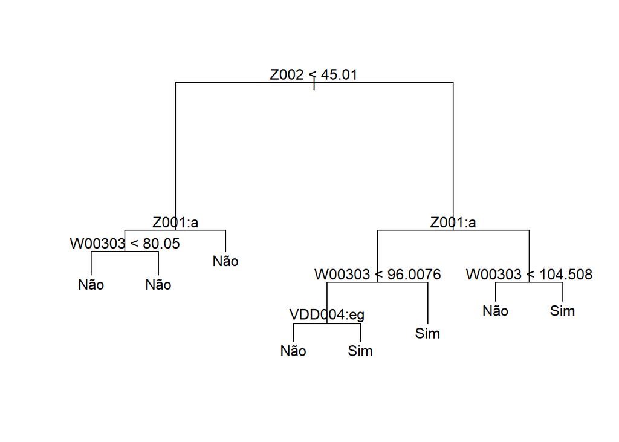

```r
plot(Arvore_dec_mod_4)

text(Arvore_dec_mod_4)
```

```r
Arvore_dec_mod_4
```

```
## node), split, n, deviance, yval, (yprob)
##       * denotes terminal node
##
##  1) root 9180 12720.0 Não ( 0.50664 0.49336 )
##    2) Z002 < 45.01 3148  3438.0 Não ( 0.76429 0.23571 )
##      4) Z001: F 2142  2628.0 Não ( 0.69701 0.30299 )
##        8) W00303 < 80.05 552   307.0 Não ( 0.92029 0.07971 ) *
##        9) W00303 > 80.05 1590  2113.0 Não ( 0.61950 0.38050 ) *
##      5) Z001: M 1006   620.0 Não ( 0.90755 0.09245 ) *
##    3) Z002 > 45.01 6032  7964.0 Sim ( 0.37218 0.62782 )
##      6) Z001: F 4451  5370.0 Sim ( 0.29117 0.70883 )
##       12) W00303 < 96.0076 1883  2587.0 Sim ( 0.44450 0.55550 )
##         24) VDD004: 5,7 406   484.0 Não ( 0.71675 0.28325 ) *
##         25) VDD004: 1,2,3,4,6 1477  1946.0 Sim ( 0.36967 0.63033 ) *
##       13) W00303 > 96.0076 2568  2411.0 Sim ( 0.17874 0.82126 ) *
##      7) Z001: M 1581  2128.0 Não ( 0.60025 0.39975 )
##       14) W00303 < 104.508 1053  1262.0 Não ( 0.71320 0.28680 ) *
##       15) W00303 > 104.508 528   698.6 Sim ( 0.37500 0.62500 ) *
```

Existe um desbalanceamento entre os sexos, com mais mulheres com critérios de diabetes.

```r
table(banco_train_arv$class, banco_train_arv$Z001 )
```

```
##
##          F    M
##   Não 2789 1862
##   Sim 3804  725
```

### Arvore banco teste

```r
banco_test_arv <- banco_test %>%
  mutate(
    Z001 = as.factor(if_else(Z001 == 1, "M", "F") ),
    diabetes = as.factor(diabetes),
    VDD004 = as.factor(VDD004),
    regiao = as.factor(regiao)
  )
```

Tabela previsão vs teste.

```r
Arv_dec_test_pred <- predict(Arvore_dec_mod_4, banco_test_arv[, 1:8], type = 'class')

table(banco_test_arv$diabetes, Arv_dec_test_pred)
```

```
##      Arv_dec_test_pred
##        Não  Sim
##   Não 1461  531
##   Sim  110  166
```

Matriz de confusão no teste.

```r
caret::confusionMatrix(Arv_dec_test_pred, banco_test_arv$diabetes, positive = "Sim")
```

```
## Confusion Matrix and Statistics
##
##           Reference
## Prediction  Não  Sim
##        Não 1461  110
##        Sim  531  166
##
##                Accuracy : 0.7174
##                  95% CI : (0.6983, 0.7358)
##     No Information Rate : 0.8783
##     P-Value [Acc > NIR] : 1
##
##                   Kappa : 0.2021
##
##  Mcnemar's Test P-Value : <2e-16
##
##             Sensitivity : 0.60145
##             Specificity : 0.73343
##          Pos Pred Value : 0.23816
##          Neg Pred Value : 0.92998
##              Prevalence : 0.12169
##          Detection Rate : 0.07319
##    Detection Prevalence : 0.30732
##       Balanced Accuracy : 0.66744
##
##        'Positive' Class : Sim
##
```

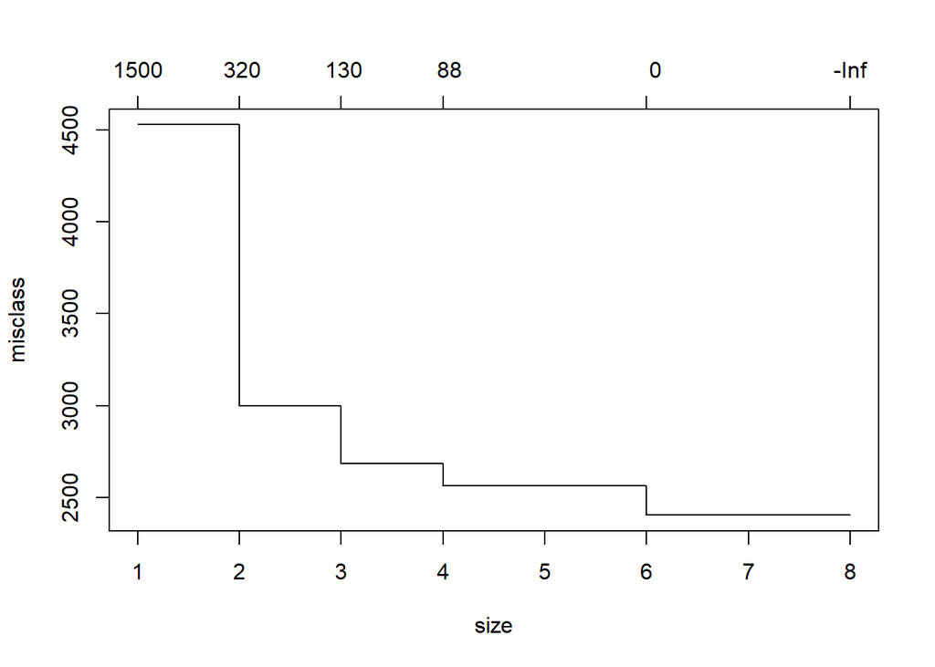

```r
Cross_validation <- tree::cv.tree(Arvore_dec_mod_4, FUN=prune.misclass, K = 10)

plot(Cross_validation)
```

Árvore podada.

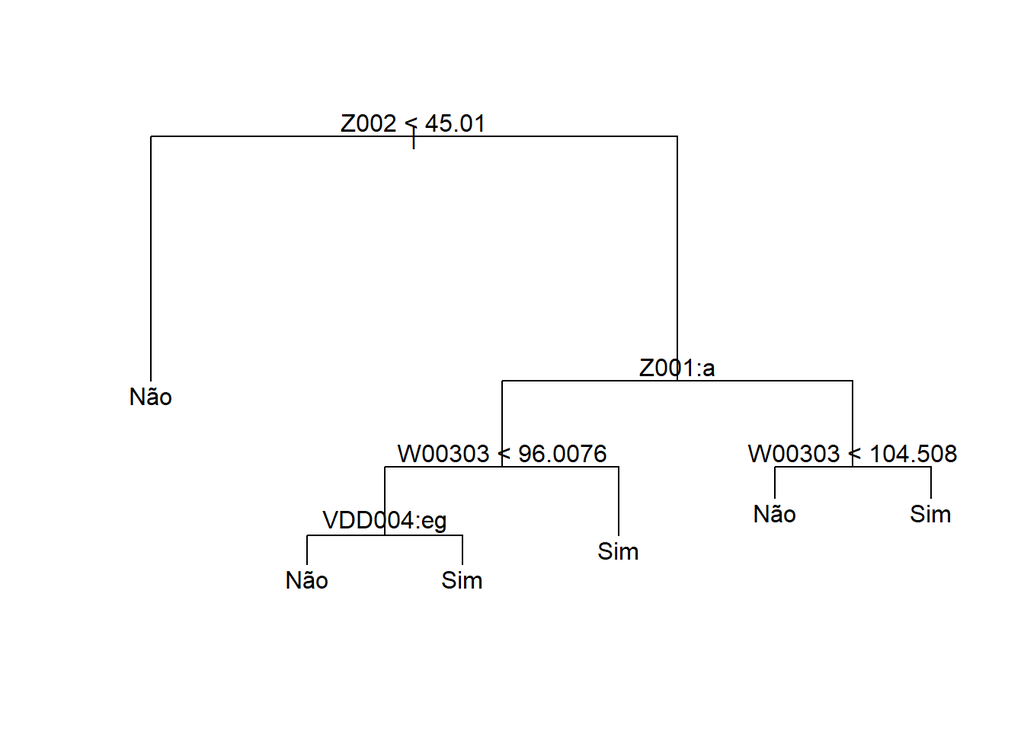

```r
ArvorePodada = prune.misclass(Arvore_dec_mod_4, best =6)

plot(ArvorePodada)
text(ArvorePodada)
```

```r
ArvorePodada
```

```
## node), split, n, deviance, yval, (yprob)
##       * denotes terminal node
##
##  1) root 9180 12720.0 Não ( 0.5066 0.4934 )
##    2) Z002 < 45.01 3148  3438.0 Não ( 0.7643 0.2357 ) *
##    3) Z002 > 45.01 6032  7964.0 Sim ( 0.3722 0.6278 )
##      6) Z001: F 4451  5370.0 Sim ( 0.2912 0.7088 )
##       12) W00303 < 96.0076 1883  2587.0 Sim ( 0.4445 0.5555 )
##         24) VDD004: 5,7 406   484.0 Não ( 0.7167 0.2833 ) *
##         25) VDD004: 1,2,3,4,6 1477  1946.0 Sim ( 0.3697 0.6303 ) *
##       13) W00303 > 96.0076 2568  2411.0 Sim ( 0.1787 0.8213 ) *
##      7) Z001: M 1581  2128.0 Não ( 0.6003 0.3997 )
##       14) W00303 < 104.508 1053  1262.0 Não ( 0.7132 0.2868 ) *
##       15) W00303 > 104.508 528   698.6 Sim ( 0.3750 0.6250 ) *
```

# Considerações finais

- O R não trabalha muito bem com “*character*”; é melhor trabalhar com as variáveis como *factor* ou *numeric* e somente na última fazer modificar os labels;
- Nosso modelo está alinhado com o modelo teórico, como no artigo de referência(NASCIMENTO et al., 2003).

  A circunferência abdominal tem uma relação maior com o diagnóstico de DM do que o IMC. O VLDL também tem elevada associação com o DM.
- Há um problema com desbalanceamento entre os gêneros (masculino e femino), Muito mais mulheres com dianóstico de diabetes do homens.

  ```
   Na construção da árvore parece que somente o fato de ser homem já reduz a possibilidade de DM.
  ```

# Referências

DZIURA, J. D. et al. Strategies for dealing with missing data in clinical trials: from design to analysis. *The Yale journal of biology and medicine*, v. 86, n. 3, p. 343, 2013.

FORTI, A. et al. Diretrizes da Sociedade Brasileira de Diabetes 2019-2020 [Internet]. *São Paulo: Clannad*, 2020.

NASCIMENTO, R. do et al. Diabetes mellitus tipo 2: fatores preditivos na população nipo-brasileira. *Arquivos Brasileiros de Endocrinologia & Metabologia*, v. 47, n. 5, p. 584–592, 2003.